# Performing queries on the ‘Ecoulement’ API

Pascal Irz & David Dorchies

2025-04-28

This vignette shows how to use the [`hubeau` R package](https://github.com/inrae/hubeau) in order to retrieve data from the French streams drought monitoring network ([Observatoire National Des Etiage, ONDE](https://onde.eaufrance.fr/)) from the [API “Ecoulement des cours d’eau”](https://hubeau.eaufrance.fr/page/api-ecoulement) of the [Hub’eau](https://hubeau.eaufrance.fr/) portal.

Nationwide, this network encompasses 3000+ observation sites, that are streams stretches selected to reflect the severity of drought events, i.e. that flow in “normal” conditions but dry out in case of drought. Located at the upstream of the river basins, these sites are expected to act as ‘sentinels’ and to provide early warning of the necessity of restricting water withdrawal in rivers and associated water tables.

We illustrate the use of this API for the departement of Ille-et-Vilaine (`code_departement=35`) with some example of maps and charts useful for the interpretation of these data.

```r
my_dept <- "35"
```

# Getting started

First, we need to load the packages used in this vignette for processing data and display results on charts and map:

```r
library(hubeau)

library(dplyr)
library(sf)
```

```r
library(mapview)
library(ggplot2)
```

“Ecoulement” is one of the 11 APIs that can be queried with the `{hubeau}` R package. These APIs can be listed using the `list_apis()` function.

```r
list_apis()
```

```
#>  [1] "prelevements"         "indicateurs_services" "hydrometrie"
#>  [4] "niveaux_nappes"       "poisson"              "ecoulement"
#>  [7] "hydrobio"             "temperature"          "qualite_eau_potable"
#> [10] "qualite_nappes"       "qualite_rivieres"
```

The list of the API endpoints is provided by the function `list_endpoints`.

```r
list_endpoints(api = "ecoulement")
```

```
#> [1] "stations"     "observations" "campagnes"
```

- `stations` lists the monitoring stations
- `campagnes` lists the surveys
- `observations` is the data itself, indicating if, at the date of the survey, the river flows or if it is dry (which is assessed visually in the field)

`station` and `observations` can be joined *at least* by the field `code_station`.

`observations` and `campagne` can be joined by the field `code_campagne`.

For each endpoint, the function `list_params()` gives the different parameters that can be retrieved.

```r
list_params(api = "ecoulement",
            endpoint = "observations")
```

```
#>  [1] "format"               "code_station"         "libelle_station"
#>  [4] "code_departement"     "libelle_departement"  "code_commune"
#>  [7] "libelle_commune"      "code_region"          "libelle_region"
#> [10] "code_bassin"          "libelle_bassin"       "code_cours_eau"
#> [13] "libelle_cours_eau"    "code_campagne"        "code_reseau"
#> [16] "libelle_reseau"       "date_observation_min" "date_observation_max"
#> [19] "code_ecoulement"      "libelle_ecoulement"   "longitude"
#> [22] "latitude"             "distance"             "bbox"
#> [25] "sort"                 "page"                 "size"
#> [28] "fields"               "Accept"
```

# Retrieving the data

## Sites

Retrieve the available fields.

```r
param_stations <- paste(
    list_params(api = "ecoulement", endpoint = "stations"),
    collapse = ","
)
```

Download the data.

```r
stations <- get_ecoulement_stations(
  code_departement = my_dept,
  fields = param_stations
)
```

The `stations` dataframe is transformed into a `sf` geographical object, then mapped.

```r
stations_geo <- stations %>%
  select(code_station,
         libelle_station,
         longitude,
         latitude) %>%
  sf::st_as_sf(coords = c("longitude", "latitude"), crs = 4326)

mapview::mapview(
  stations_geo,
  popup = leafpop::popupTable(
    stations_geo,
    zcol = c("code_station", "libelle_station"),
    feature.id = FALSE,
    row.numbers = FALSE
  ),
  label = "libelle_station",
  legend = FALSE
)
```

[interactive chart not shown]

## Surveys

A survey encompasses a series of visual observations carried out on stations at the “departement” grain. It is tagged as “usuelle” if it is a routine (i.e. around the 24th of the month from May to September), as “complémentaire” if not (e.g. during very dry periods).

Download the `surveys` dataframe.

```r
surveys <- get_ecoulement_campagnes(
  code_departement = my_dept, # department id
  date_campagne_min = "2012-01-01" # start date
  )
```

```r
surveys <- surveys %>%
  mutate(code_campagne = as.factor(code_campagne),
         year = lubridate::year(date_campagne),
         month = lubridate::month(date_campagne)) %>%
    select(code_campagne,
           year,
           month,
           libelle_type_campagne)
```

Visualise a few rows.

```r
surveys %>%
  head() %>%
  knitr::kable()
```

| code_campagne | year | month | libelle_type_campagne |
| --- | --- | --- | --- |
| 96911 | 2022 | 10 | complémentaire |
| 96868 | 2022 | 10 | complémentaire |
| 96831 | 2022 | 9 | usuelle |
| 96724 | 2022 | 9 | complémentaire |
| 96652 | 2022 | 8 | usuelle |
| 96562 | 2022 | 8 | complémentaire |

## Observations

Retrieve the available fields.

```r
param_obs <- paste(
    list_params(api = "ecoulement", endpoint = "observations"),
    collapse = ","
)
```

Download the data.

```r
observations <-
  get_ecoulement_observations(
    code_departement = my_dept,
    date_observation_min = "2012-01-01",
    fields = param_obs
  )
```

```r
observations <- observations %>%
  filter(!is.na(code_ecoulement)) %>%
  mutate(code_campagne = as.factor(code_campagne))
```

# Graphical output of monthly indicator

We first need to join survey and observation data:

```r
obs_and_surv <- observations %>%
  left_join(surveys, by = join_by(code_campagne)) %>%
  select(code_station, libelle_station, year, month, code_ecoulement)
```

And, in case of several observations during the same month, we keep the driest status:

```r
obs_and_surv <- obs_and_surv %>%
  arrange(code_ecoulement) %>%
  group_by(code_station, libelle_station, year, month) %>%
  summarise(code_ecoulement = last(code_ecoulement), .groups = 'drop')
```

The flow observations codes are translated in English:

```r
flow_labels <- c(
  "1"  = "Visible flow",
  "1a" = "Decent visible flow",
  "1f" = "Weak visible flow",
  "2"  = "No visible flow",
  "3"  = "Dry"
)
obs_and_surv$flow_label <- flow_labels[obs_and_surv$code_ecoulement]
```

Custom plot function.

```r
gg_stream_flow <-
  function(sel_station, data) {

    # selected data
    sel_data <- data %>%
      filter(code_station == sel_station) %>%
      mutate(flow_label = factor(flow_label, levels = flow_labels))

    # station name for plot title
    station_lab <- unique(sel_data$libelle_station)

    # year range
    year_range <-
      min(sel_data$year, na.rm = T):max(sel_data$year, na.rm = T)

    # plot
    sel_data %>%
      ggplot(aes(x = month,
                 y = year,
                 color = flow_label)) +
      geom_point(shape = 15, size = 7) +
      scale_color_manual(name = "Flow status",
                         values = c("blue",
                                    "deepskyblue",
                                    "lightblue",
                                    "orange",
                                    "red"),
                         labels = flow_labels,
                         drop = FALSE) +
      scale_x_continuous(breaks = 1:12,
                         labels = 1:12,
                         limits = c(1, 12)) +
      scale_y_continuous(breaks = year_range,
                         labels = year_range) +
      labs(x = "Months",
           y = "Years",
           title = sprintf("%s (%s)", station_lab, sel_station)) +
      theme(
        axis.line = element_line(color = 'black'),
        plot.background = element_blank(),
        panel.grid.minor = element_blank(),
        panel.grid.major.x = element_line(linewidth = 0.5,
                                          colour = "black"),
        panel.border = element_blank()
      )
  }
```

Display plot for all stations that contain at least one observation with “Dry” status.

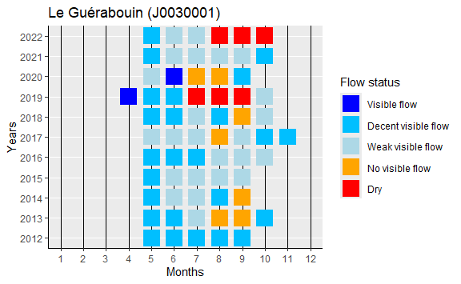

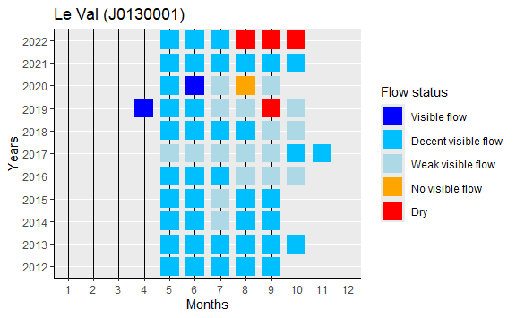

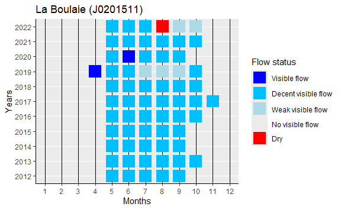

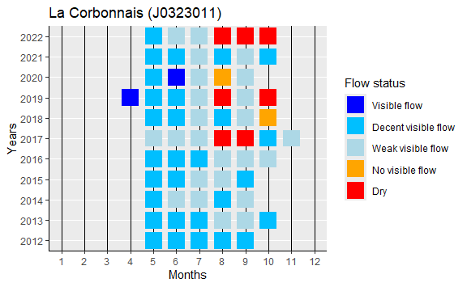

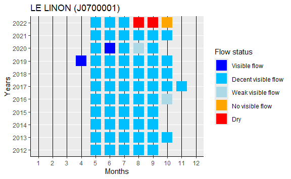

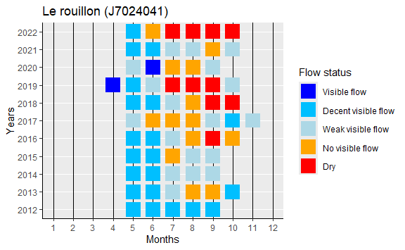

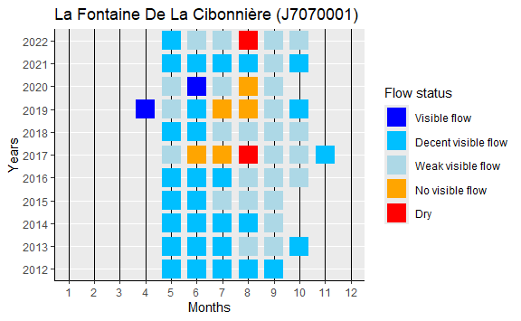

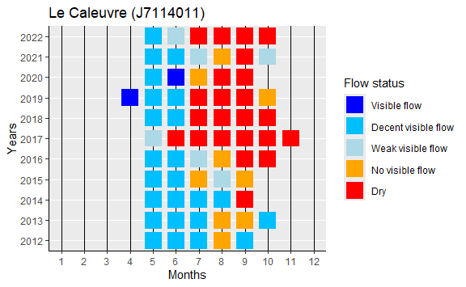

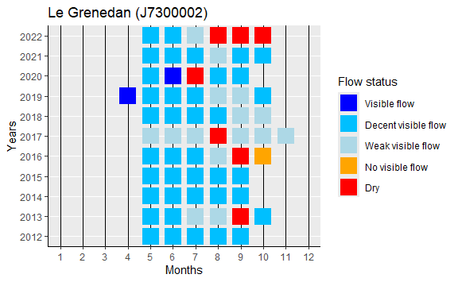

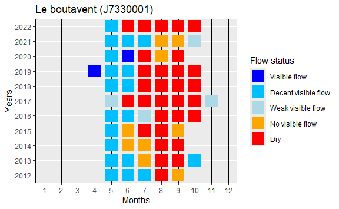

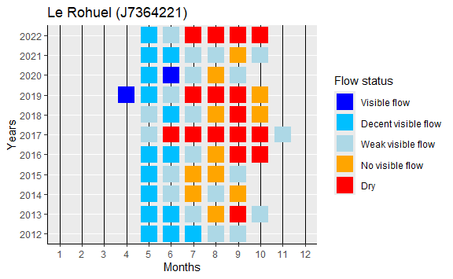

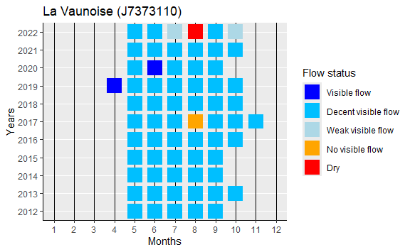

[11 more figures not shown]

```r
dry_stations <- obs_and_surv %>%
  filter(code_ecoulement == "3") %>%
  pull(code_station) %>% unique

lapply(dry_stations, gg_stream_flow, data = obs_and_surv)
```